# Homework 9

*Enter your name and EID here*

**This homework is due on April 26, 2021 at 11:00pm. Please submit as a pdf file on Canvas.**

**Problem 1: (2 pts)**

Use the color picker app from the **colorspace** package (`colorspace::choose_color()`) to create a qualitative color scale containing four colors. One of the four colors should be `#5626B4`, so you need to find three additional colors that go with this one.

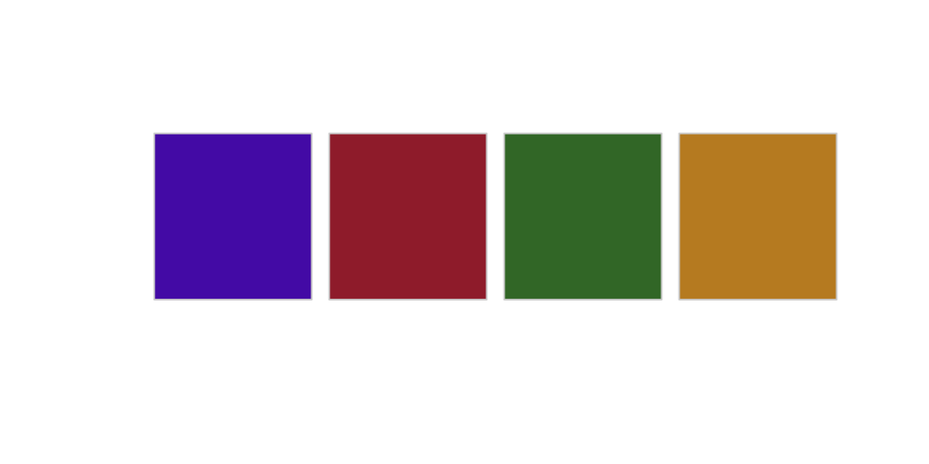

```r
colors <- c("#5626B4", "#A12B37", "#3E7732", "#C38C29")

swatchplot(colors)
```

**Problem 2: (4 pts)** Take the following scatter plot of the penguins dataset and make three modifications:

1. Use the colors you chose in Problem 1.
2. Improve the visual appearance by choosing a theme and cleaning up axis labels.
3. Remove the need for a legend by direct-labeling the points.

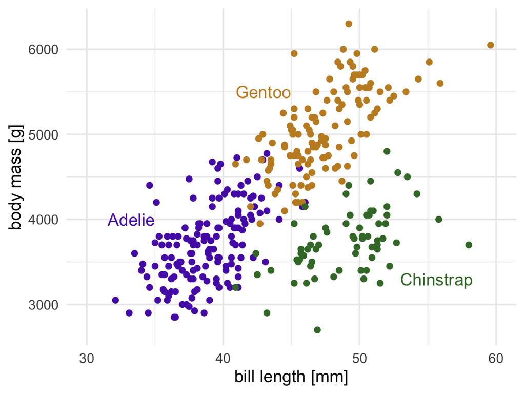

```r
labels_data <- tibble(
  species = c("Adelie", "Chinstrap", "Gentoo"),
  bill_length_mm = c(35, 53, 45),
  body_mass_g = c(4000, 3300, 5500),
  hjust = c(1, 0, 1)
)

ggplot(penguins, aes(bill_length_mm, body_mass_g, color = species)) +
  geom_point(size = 2, na.rm = TRUE) +
  geom_text(
    data = labels_data,
    aes(label = species, hjust = hjust),
    size = 14/.pt
  ) +
  scale_x_continuous(
    name = "bill length [mm]",
    limits = c(30, 60)
  ) +
  scale_y_continuous(
    name = "body mass [g]"
  ) +
  scale_color_manual(values = colors[c(1, 3, 4)], guide = "none") +
  theme_minimal(14)
```

**Problem 3: (4 pts)** The following scatter plot shows per-capita income versus number of inhabitants in all Texas counties in 2010. Use `geom_text_repel()` to label a subset of the counties by name. You can choose the counties to subset as you wish. Also, choose a theme and clean up the axis labeling, and make any other improvements to the plot design you consider appropriate.

**Hint:** If you’re not sure how to select a subset of counties to label, check out the examples on the **ggrepel** website for some inspiration: https://ggrepel.slowkow.com/articles/examples.html#examples-1

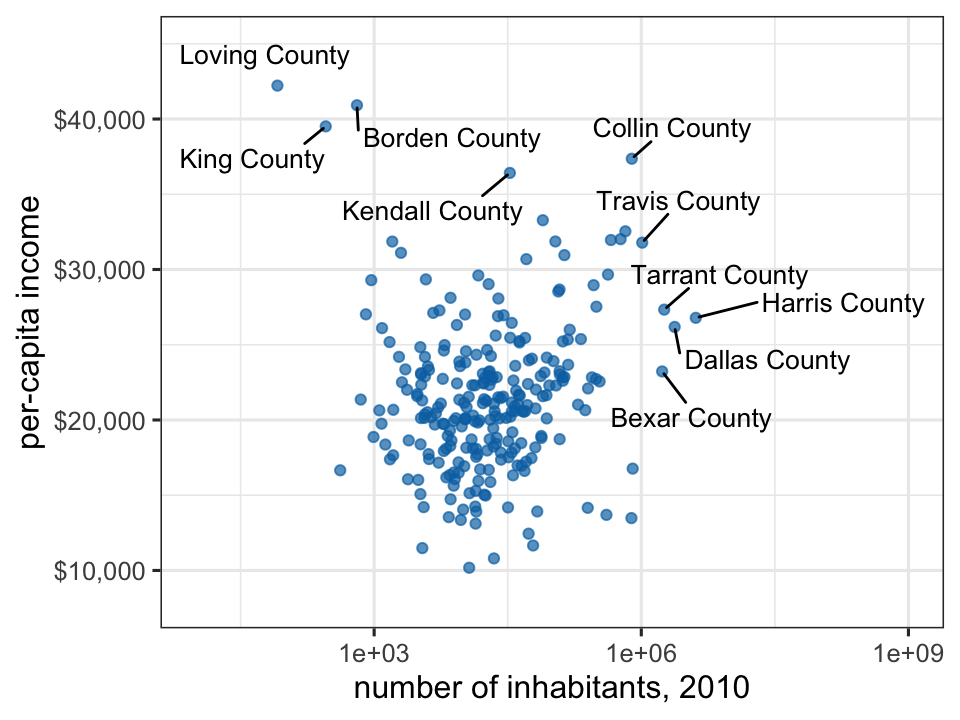

```r
tx_census <- read_csv("https://wilkelab.org/SDS375/datasets/US_census.csv") %>%
  filter(state == "Texas") %>%
  select(county = name, pop2010, per_capita_income)

set.seed(1234)

tx_census %>%
  mutate(
    # randomly label 20% as well as the most extreme caess
    label = ifelse(
      per_capita_income > 35000 |
        pop2010 > 1e6,
      county, ""
    )
  ) %>%
  ggplot(aes(pop2010, per_capita_income)) +
  geom_point(size = 1.5, color = "#0072B2B0") +
  geom_text_repel(
    aes(label = label),
    max.overlaps = Inf,
    box.padding = .5,
    force = 5,
    size = 10/.pt
  ) +
  scale_x_log10(
    name = "number of inhabitants, 2010",
    limits = c(1e1, 1e9)
  ) +
  scale_y_continuous(
    name = "per-capita income",
    labels = scales::dollar_format(),
    limits = c(8000, 45000)
  ) +
  theme_bw(12)
```